# NESE Post-Breeding females: foraging strategies, independent validation and domain niches

Luis Huckstadt

2026-11-02

# 1 Overview

This workflow redesigns the Post-Breeding analysis so that the variables that **define** the foraging strategies are kept separate from the variables used to **test** and **characterise** them. (Robustness of the number of dimensions and clusters is in `NESE_HCPC_PostBreeding_Robustness.Rmd`.)

| Step | What | Role |
| --- | --- | --- |
| 2 | MFA (space + diving blocks, equal weight) + HCPC | defines strategies |
| 3 | Gaussian mixture on the MFA space | membership probabilities |
| 4 | Isotopes, mass gain, trip duration, morphology, year | **independent** validation |
| 5 | Repeat seals (PB–PB, PB→PM) | individual consistency |
| 6.1 | Isotopic niche (nicheROVER, SEA) | **independent** niche comparison |
| 6.2 | Spatial niche (utilisation distributions) | descriptive |
| 6.3 | Diving niche | descriptive |
| 6.4 | Null model for niche overlap | quantifies circularity |

Stable isotopes, mass gain and trip duration are **not** used to build the clusters, so differences in them are genuine tests. Spatial and diving niches are partly determined by the clustering itself and are reported as descriptions, with a null model (6.4) showing how much overlap would be expected from clustering alone.

```r
library(dplyr)
library(tidyr)
library(ggplot2)
library(FactoMineR)
library(cluster)     # clusGap, silhouette
library(mclust)      # Mclust, adjustedRandIndex
library(nicheROVER)
library(sf)
# MASS is used with MASS:: to avoid masking dplyr::select
```

## 1.1 Settings

```r
SEED         <- 20261102
K            <- 3        # number of strategies (see robustness Rmd)
N_DIM        <- 4        # MFA dimensions used for clustering (parallel analysis / broken stick)
N_BOOT       <- 50#500      # bootstrap replicates for cluster stability
N_PERM       <- 499#4999     # permutations for Freedman-Lane tests
N_POST       <- 2000#1e4      # nicheROVER posterior draws
N_SIM        <- 20#200      # simulations for the overlap null model
UNCERTAIN_Z  <- 0.80     # seals with max membership probability below this are "uncertain"

# Equivalence margins (permil) for "the two offshore strategies feed at the same
# isotopic position". These are a biological judgement: justify them in the
# paper (e.g. inter-annual baseline variability, or a fraction of a 3-3.5 permil
# trophic step for d15N).
EQUIV <- c(d13C = 0.3, d15N = 0.5)

# Spatial utilisation distributions
LAEA             <- "+proj=laea +lat_0=45 +lon_0=-140 +units=km +datum=WGS84"
COLONY_LONLAT    <- c(-122.33, 37.11)   # Año Nuevo
COLONY_BUFFER_KM <- 100                 # drop locations near the colony (as in track2KBA tripSplit)
KERNEL_SD_KM     <- 50                  # kernel standard deviation (common to all seals)
KERNEL_SD_SENS   <- c(25, 50, 100)      # bandwidth sensitivity
CELL_KM          <- 25

OUT <- "../results/strategies_validation"
FIG <- "../figures/strategies_validation"
dir.create(OUT, recursive = TRUE, showWarnings = FALSE)
dir.create(FIG, recursive = TRUE, showWarnings = FALSE)
set.seed(SEED)
```

# 2 Data

```r
SPACE <- c("MaxLat_degrees", "MinLon_degrees",
           "MedianDistToContShelf_km", "SdDistContShelf_km",
           "MesoEcoProportionShelf", "MesoEcoProportionCAC",
           "MesoEcoProportionSubArcticPac", "MesoEcoProportionNorthCPac")
DIVE  <- c("Mean_Depth_m", "Mean_Depth_sd", "Mean_Duration_sec", "Mean_Duration_sd",
           "Pct_TransitDives", "Pct_ForagingDives", "Pct_DriftDives", "Pct_BenthicDives",
           "PctTripDiving", "DeepDayForageDivesMedian_m", "DeepNightForageDivesMedian_m")
ISO   <- c("d13C", "d15N")
BEHAV <- c(SPACE, DIVE)
META  <- c("MainID", "AgeDeploy", "StandardLength_cm", "Mass_Procedure_kg",
           "MassGainRate_kgPerDay_Dcrocker", "TripDuration_days")
```

```r
f.PCAdata.1 <- readRDS("../data/f.PCAdata.1.rds") %>%
  mutate(TOPPID = as.character(TOPPID))

meta <- read.csv("../data/IsotopesDatasetForLuis_2023_4_4.csv") %>%
  mutate(TOPPID = as.character(TOPPID), MainID = as.character(MainID)) %>%
  dplyr::select(TOPPID, all_of(META)) %>%
  distinct(TOPPID, .keep_all = TRUE)

all_trips <- f.PCAdata.1 %>% left_join(meta, by = "TOPPID") %>%
  mutate(ProcedureYear = factor(ProcedureYear))

dat <- all_trips %>% filter(Trip == "PostBreeding") %>% as.data.frame()
rownames(dat) <- dat$TOPPID

stopifnot(all(c(BEHAV, ISO) %in% names(dat)),
          !anyDuplicated(dat$TOPPID),
          all(complete.cases(dat[c(BEHAV, ISO)])))
n <- nrow(dat)
cat(n, "Post-Breeding trips from", n_distinct(dat$MainID), "seals;",
    sum(is.na(dat$MainID)), "trips without MainID\n")
```

```
## 93 Post-Breeding trips from 87 seals; 0 trips without MainID
```

```r
# Original PCA-HCPC assignment, for comparison
orig <- read.csv("../results/PB_Clusters.csv") %>%
  mutate(TOPPID = as.character(TOPPID)) %>% dplyr::select(TOPPID, cluster)
dat$orig_cluster <- as.integer(sub("Cluster ", "", orig$cluster[match(dat$TOPPID, orig$TOPPID)]))
```

## 2.1 Data checks

```r
# Mesoecoregion proportions are compositional (sum to 1): one is redundant.
summary(rowSums(dat[grep("MesoEco", SPACE, value = TRUE)]))
```

```
##    Min. 1st Qu.  Median    Mean 3rd Qu.    Max.
##       1       1       1       1       1       1
```

```r
# Dive-type percentages do NOT always sum to ~100: check the definition
# (unclassified dives?) before interpreting them.
summary(rowSums(dat[c("Pct_TransitDives", "Pct_ForagingDives",
                      "Pct_DriftDives", "Pct_BenthicDives")]))
```

```
##    Min. 1st Qu.  Median    Mean 3rd Qu.    Max.
##   34.06   94.01   96.19   93.93   97.39   99.18
```

```r
# Highly redundant pairs (|Spearman rho| > 0.85)
rho <- cor(dat[BEHAV], method = "spearman"); rho[upper.tri(rho, diag = TRUE)] <- NA
as.data.frame(as.table(rho)) %>% filter(abs(Freq) > 0.85) %>% arrange(desc(abs(Freq)))
```

```
##                            Var1                     Var2       Freq
## 1            SdDistContShelf_km MedianDistToContShelf_km  0.9512996
## 2 MesoEcoProportionSubArcticPac           MaxLat_degrees  0.9432758
## 3    MesoEcoProportionNorthCPac       SdDistContShelf_km  0.9066012
## 4      MedianDistToContShelf_km           MinLon_degrees -0.8899913
## 5    MesoEcoProportionNorthCPac MedianDistToContShelf_km  0.8814287
```

```r
# Mass gain rate is correlated with trip duration: duration is a covariate below
cor.test(dat$MassGainRate_kgPerDay_Dcrocker, dat$TripDuration_days, method = "spearman")
```

```
##
##  Spearman's rank correlation rho
##
## data:  dat$MassGainRate_kgPerDay_Dcrocker and dat$TripDuration_days
## S = 189158, p-value = 4.948e-05
## alternative hypothesis: true rho is not equal to 0
## sample estimates:
##        rho
## -0.4111635
```

## 2.2 Helper functions

```r
# MFA on the behavioural blocks; isotopes optionally as a supplementary group
mfa_fit <- function(d, ncp = N_DIM, sup_iso = TRUE, ind.sup = NULL) {
  base <- d[, c(SPACE, DIVE, if (sup_iso) ISO)]
  rownames(base) <- NULL
  MFA(base,
      group = c(length(SPACE), length(DIVE), if (sup_iso) length(ISO)),
      type = rep("s", 2 + sup_iso),
      name.group = c("Space", "Diving", if (sup_iso) "Isotopes"),
      num.group.sup = if (sup_iso) 3 else NULL,
      ind.sup = ind.sup, ncp = ncp, graph = FALSE)
}
mfa_coords <- function(d, ncp = N_DIM) mfa_fit(d, ncp, sup_iso = FALSE)$ind$coord[, 1:ncp, drop = FALSE]

# Ward + k-means consolidation (= FactoMineR::HCPC), fast enough for loops
hcpc_lite <- function(S, k) {
  cl  <- cutree(hclust(dist(S), method = "ward.D2"), k)
  cen <- apply(S, 2, function(x) tapply(x, cl, mean))
  kmeans(S, centers = cen, iter.max = 100)$cluster
}
# HCPC automatic rule: minimise W(k)/W(k-1)
hcpc_ratio <- function(S, kmin = 2, kmax = 8) {
  h <- hclust(dist(S), method = "ward.D2")
  g <- sort(h$height^2 / (2 * nrow(S)), decreasing = TRUE)
  W <- sapply(1:(kmax + 1), function(k) sum(g[k:length(g)]))
  setNames(W[kmin:kmax] / W[(kmin - 1):(kmax - 1)], kmin:kmax)
}

# Relabel a partition so its labels match a reference partition as closely as possible
perms <- function(v) if (length(v) <= 1) list(v) else
  do.call(base::c, lapply(seq_along(v), function(i) lapply(perms(v[-i]), function(p) c(v[i], p))))
align_map <- function(new, ref) {        # returns map: map[new_label] = ref_label
  k <- max(new, ref)
  tab <- table(factor(new, 1:k), factor(ref, 1:k))
  P <- perms(1:k)
  P[[which.max(sapply(P, function(p) sum(tab[cbind(1:k, p)])))]]
}

# Freedman-Lane permutation F test for `term`, adjusting for `covars`
fl_test <- function(d, response, term = "strategy", covars = character(0), B = N_PERM) {
  v  <- c(response, term, covars)
  d  <- d[complete.cases(d[v]), v, drop = FALSE]
  X0 <- model.matrix(reformulate(if (length(covars)) covars else "1"), d)
  X1 <- model.matrix(reformulate(c(covars, term)), d)
  y  <- d[[response]]
  Fstat <- function(y) {
    m0 <- lm.fit(X0, y); m1 <- lm.fit(X1, y)
    r0 <- sum(m0$residuals^2); r1 <- sum(m1$residuals^2)
    ((r0 - r1) / (m1$rank - m0$rank)) / (r1 / (nrow(X1) - m1$rank))
  }
  F_obs <- Fstat(y)
  m0  <- lm.fit(X0, y); fit0 <- y - m0$residuals
  F_p <- replicate(B, Fstat(fit0 + sample(m0$residuals)))
  data.frame(response = response,
             covariates = if (length(covars)) paste(covars, collapse = " + ") else "none",
             n = nrow(d), F = F_obs, p_perm = (1 + sum(F_p >= F_obs)) / (B + 1))
}

# All pairwise contrasts between levels of `term` from an lm, with CIs
pair_contrasts <- function(fit, term = "strategy", level = 0.95) {
  b <- coef(fit); V <- vcov(fit)
  lev <- levels(model.frame(fit)[[term]]); cn <- paste0(term, lev)
  tq <- qt(1 - (1 - level) / 2, fit$df.residual)
  do.call(rbind, combn(seq_along(lev), 2, simplify = FALSE, FUN = function(ij) {
    L <- setNames(numeric(length(b)), names(b))
    if (cn[ij[2]] %in% names(b)) L[cn[ij[2]]] <- 1
    if (cn[ij[1]] %in% names(b)) L[cn[ij[1]]] <- L[cn[ij[1]]] - 1
    est <- sum(L * b); se <- sqrt(drop(t(L) %*% V %*% L))
    data.frame(contrast = paste(lev[ij[2]], "-", lev[ij[1]]),
               estimate = est, lwr = est - tq * se, upr = est + tq * se)
  }))
}

# Plug-in Monte Carlo overlap: P(draw from niche i falls in alpha-region of niche j)
plugin_overlap <- function(S, cl, alpha = 0.95, N = 5000) {
  S <- as.matrix(S); cl <- as.character(cl); g <- sort(unique(cl)); q <- qchisq(alpha, ncol(S))
  par <- lapply(g, function(k) list(mu = colMeans(S[cl == k, , drop = FALSE]),
                                    Sig = cov(S[cl == k, , drop = FALSE])))
  O <- matrix(NA, length(g), length(g), dimnames = list(g, g))
  for (i in seq_along(g)) {
    Y <- MASS::mvrnorm(N, par[[i]]$mu, par[[i]]$Sig)
    for (j in seq_along(g)) O[i, j] <- mean(mahalanobis(Y, par[[j]]$mu, par[[j]]$Sig) <= q)
  }
  O
}
offdiag_mean <- function(O) mean(O[row(O) != col(O)])
```

# 3 Defining the strategies: MFA on space + diving

Multiple Factor Analysis weights each block by the inverse of its first eigenvalue, so the spatial (8 variables) and diving (11 variables) blocks contribute equally, however many variables were measured in each. Isotopes are projected as a **supplementary** group: they are shown on the factor map but do not influence the solution.

```r
res.mfa <- mfa_fit(dat, ncp = N_DIM)
round(head(res.mfa$eig, 8), 3)
```

```
##        eigenvalue percentage of variance cumulative percentage of variance
## comp 1      1.588                 31.443                            31.443
## comp 2      0.950                 18.812                            50.255
## comp 3      0.635                 12.576                            62.831
## comp 4      0.554                 10.969                            73.800
```

```r
res.mfa$group$RV          # similarity between blocks (incl. supplementary isotopes)
```

```
##              Space     Diving   Isotopes       MFA
## Space    1.0000000 0.31893375 0.13461003 0.7469321
## Diving   0.3189338 1.00000000 0.05290327 0.8683991
## Isotopes 0.1346100 0.05290327 1.00000000 0.1075400
## MFA      0.7469321 0.86839913 0.10753998 1.0000000
```

```r
round(res.mfa$group$contrib, 1)
```

```
##        Dim.1 Dim.2 Dim.3 Dim.4
## Space   51.4  14.3  42.9  18.4
## Diving  48.6  85.7  57.1  81.6
```

```r
round(res.mfa$quanti.var.sup$cor, 2)   # isotopes vs MFA dimensions
```

```
##      Dim.1 Dim.2 Dim.3 Dim.4
## d13C  0.16  0.31  0.32 -0.25
## d15N -0.08  0.18  0.23 -0.27
```

```r
S <- res.mfa$ind$coord[, 1:N_DIM]
```

## 3.1 Number of clusters on the MFA space

```r
round(hcpc_ratio(S), 3)        # HCPC rule (minimum = suggested k)
```

```
##     2     3     4     5     6     7     8
## 0.695 0.771 0.836 0.837 0.870 0.878 0.882
```

```r
gs <- clusGap(S, FUNcluster = function(x, k) list(cluster = hcpc_lite(x, k)),
              K.max = 8, B = 200, spaceH0 = "scaledPCA", verbose = FALSE)
cat("Gap statistic (Tibshirani 1-SE) k =",
    maxSE(gs$Tab[, "gap"], gs$Tab[, "SE.sim"], method = "Tibs2001SEmax"), "\n")
```

```
## Gap statistic (Tibshirani 1-SE) k = 2
```

```r
sapply(2:6, function(k) c(k = k, min_size = min(table(hcpc_lite(S, k))),
                          silhouette = round(mean(silhouette(hcpc_lite(S, k), dist(S))[, 3]), 3)))
```

```
##              [,1]  [,2]  [,3]  [,4]  [,5]
## k           2.000 3.000 4.000 5.000 6.000
## min_size   40.000 7.000 1.000 1.000 1.000
## silhouette  0.332 0.368 0.371 0.294 0.288
```

## 3.2 HCPC and comparison with the original PCA solution

```r
res.hcpc <- HCPC(res.mfa, nb.clust = K, consol = TRUE, graph = FALSE)
cl_raw <- as.integer(res.hcpc$data.clust$clust)

# Label strategies to match the original cluster numbers where possible
map <- if (all(!is.na(dat$orig_cluster))) align_map(cl_raw, dat$orig_cluster) else 1:K
dat$strategy <- factor(paste0("C", map[cl_raw]), levels = paste0("C", 1:K))
table(dat$strategy)
```

```
##
## C1 C2 C3
## 39 47  7
```

```r
cat("ARI with original PCA-HCPC clusters:",
    round(adjustedRandIndex(dat$strategy, dat$orig_cluster), 3), "\n")
```

```
## ARI with original PCA-HCPC clusters: 0.975
```

```r
# Which strategy is coastal? (highest California Current use)
COASTAL <- names(which.max(tapply(dat$MesoEcoProportionCAC, dat$strategy, mean)))
OFFSHORE <- setdiff(levels(dat$strategy), COASTAL)
dat %>% group_by(strategy) %>%
  summarise(n = n(), across(grep("MesoEco", SPACE, value = TRUE), ~ round(mean(.x), 2)))
```

```
## # A tibble: 3 × 6
##   strategy     n MesoEcoProportionShelf MesoEcoProportionCAC
##   <fct>    <int>                  <dbl>                <dbl>
## 1 C1          39                   0.02                 0.34
## 2 C2          47                   0.02                 0.41
## 3 C3           7                   0.11                 0.76
## # ℹ 2 more variables: MesoEcoProportionSubArcticPac <dbl>,
## #   MesoEcoProportionNorthCPac <dbl>
```

## 3.3 Cluster stability (whole-pipeline bootstrap)

Each replicate resamples seals and re-runs MFA + clustering. Mean Jaccard > 0.75 = stable, > 0.85 = highly stable, < 0.5 = dissolved (Hennig 2007).

```r
ref <- as.integer(dat$strategy)
J <- matrix(NA, N_BOOT, K)
for (b in 1:N_BOOT) {
  ix <- unique(sample(n, replace = TRUE))
  cb <- hcpc_lite(mfa_coords(dat[ix, ]), K)
  for (cc in 1:K) {
    A <- ix[ref[ix] == cc]
    if (length(A)) J[b, cc] <- max(sapply(unique(cb), function(j) {
      Bj <- ix[cb == j]; length(intersect(A, Bj)) / length(union(A, Bj)) }))
  }
}
jac <- data.frame(strategy = levels(dat$strategy), n = as.vector(table(dat$strategy)),
                  jaccard_mean = colMeans(J, na.rm = TRUE),
                  P_dissolved = colMeans(J < 0.5, na.rm = TRUE))
jac
```

```
##   strategy  n jaccard_mean P_dissolved
## 1       C1 39    0.9864311        0.00
## 2       C2 47    0.9421551        0.00
## 3       C3  7    0.7941082        0.16
```

```r
write.csv(jac, file.path(OUT, "jaccard_MFA.csv"), row.names = FALSE)
```

## 3.4 Sensitivity: reduced variable set

Drop the most redundant spatial variables (SD of distance to shelf, ρ = 0.95 with the median; the North Central Pacific proportion, implied by the other three mesoecoregion proportions).

```r
SPACE_FULL <- SPACE
SPACE <- setdiff(SPACE_FULL, c("SdDistContShelf_km", "MesoEcoProportionNorthCPac"))
cl_red <- hcpc_lite(mfa_coords(dat), K)
SPACE <- SPACE_FULL
cat("Reduced set: sizes", table(cl_red), "; ARI with main solution",
    round(adjustedRandIndex(cl_red, dat$strategy), 3), "\n")
```

```
## Reduced set: sizes 47 40 6 ; ARI with main solution 0.935
```

## 3.5 Strategy profiles

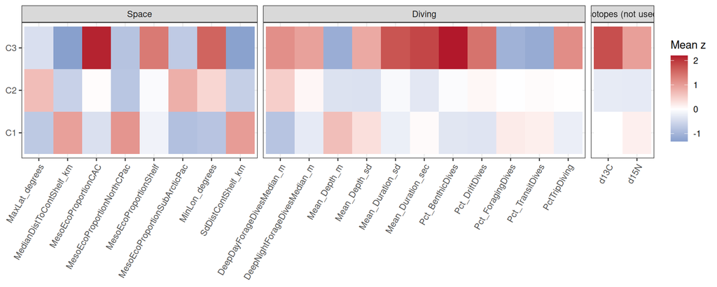

```r
prof <- data.frame(scale(dat[c(SPACE, DIVE, ISO)]), strategy = dat$strategy) %>%
  pivot_longer(-strategy, names_to = "variable") %>%
  group_by(strategy, variable) %>% summarise(mean_z = mean(value), .groups = "drop") %>%
  mutate(block = case_when(variable %in% SPACE ~ "Space", variable %in% DIVE ~ "Diving",
                           TRUE ~ "Isotopes (not used)"),
         block = factor(block, c("Space", "Diving", "Isotopes (not used)")))
g <- ggplot(prof, aes(variable, strategy, fill = mean_z)) + geom_tile() +
  facet_grid(~ block, scales = "free_x", space = "free_x") +
  scale_fill_gradient2(low = "#2166ac", high = "#b2182b") + theme_bw() +
  theme(axis.text.x = element_text(angle = 60, hjust = 1)) +
  labs(x = NULL, y = NULL, fill = "Mean z")
g
```

```r
ggsave(file.path(FIG, "strategy_profiles.pdf"), g, width = 11, height = 4.5)
```

# 4 Membership probabilities (Gaussian mixture)

Hard clusters hide how confidently each seal is assigned. A Gaussian mixture fitted to the same MFA space gives each seal a probability of belonging to each strategy. BIC over G = 1–6 is shown for information; the K-component model is used for membership.

```r
summary(mclustBIC(S, G = 1:6))
```

```
## Best BIC values:
##              EVE,3       VEI,3       VEE,3
## BIC      -939.6838 -942.362670 -947.795890
## BIC diff    0.0000   -2.678875   -8.112095
```

```r
mc <- Mclust(S, G = K)
cat("Covariance model:", mc$modelName, "\n")
```

```
## Covariance model: EVE
```

```r
mmap <- align_map(mc$classification, as.integer(dat$strategy))
z <- matrix(NA, n, K, dimnames = list(dat$TOPPID, levels(dat$strategy)))
z[, mmap] <- mc$z
dat$p_member <- z[cbind(1:n, as.integer(dat$strategy))]   # prob. of own (HCPC) strategy
dat$mc_strategy <- factor(levels(dat$strategy)[mmap[mc$classification]], levels(dat$strategy))
table(HCPC = dat$strategy, Mixture = dat$mc_strategy)
```

```
##     Mixture
## HCPC C1 C2 C3
##   C1 39  0  0
##   C2  1 45  1
##   C3  0  1  6
```

```r
dat %>% group_by(strategy) %>%
  summarise(median_p = median(p_member), n_uncertain = sum(p_member < UNCERTAIN_Z))
```

```
## # A tibble: 3 × 3
##   strategy median_p n_uncertain
##   <fct>       <dbl>       <int>
## 1 C1          1.000           0
## 2 C2          1.000           5
## 3 C3          1.000           1
```

```r
dat %>% filter(p_member < UNCERTAIN_Z) %>%
  dplyr::select(TOPPID, ProcedureYear, strategy, mc_strategy, p_member)
```

```
##          TOPPID ProcedureYear strategy mc_strategy     p_member
## 2009014 2009014          2009       C2          C2 6.346869e-01
## 2011021 2011021          2011       C3          C2 3.956991e-28
## 2011016 2011016          2011       C2          C2 7.090969e-01
## 2012020 2012020          2012       C2          C1 2.454150e-01
## 2012015 2012015          2012       C2          C2 6.467773e-01
## 2012017 2012017          2012       C2          C3 1.268849e-02
```

```r
write.csv(data.frame(TOPPID = dat$TOPPID, strategy = dat$strategy, round(z, 3)),
          file.path(OUT, "membership_probabilities.csv"), row.names = FALSE)
```

# 5 Independent validation

None of these variables were used to define the strategies. Tests are Freedman–Lane permutation F tests (robust to non-normality and to the small coastal group), with Benjamini–Hochberg correction across the family. Year is a covariate for isotopes (baseline variation) and mass gain; trip duration is a covariate for mass gain rate.

```r
val_specs <- list(
  list("d13C", character(0)), list("d13C", "ProcedureYear"),
  list("d15N", character(0)), list("d15N", "ProcedureYear"),
  list("MassGainRate_kgPerDay_Dcrocker", character(0)),
  list("MassGainRate_kgPerDay_Dcrocker", "TripDuration_days"),
  list("MassGainRate_kgPerDay_Dcrocker", c("TripDuration_days", "ProcedureYear")),
  list("TripDuration_days", character(0)),
  list("AgeDeploy", character(0)),
  list("StandardLength_cm", character(0)),
  list("Mass_Procedure_kg", character(0)))

run_validation <- function(d) {
  set.seed(SEED)
  out <- do.call(rbind, lapply(val_specs, function(s) fl_test(d, s[[1]], covars = s[[2]])))
  out$p_BH <- p.adjust(out$p_perm, "BH")
  out
}
val <- run_validation(dat)
val %>% mutate(across(c(F, p_perm, p_BH), ~ signif(.x, 3)))
```

```
##                          response                        covariates  n      F
## 1                            d13C                              none 93 17.600
## 2                            d13C                     ProcedureYear 93 16.700
## 3                            d15N                              none 93  6.430
## 4                            d15N                     ProcedureYear 93  6.620
## 5  MassGainRate_kgPerDay_Dcrocker                              none 93  7.160
## 6  MassGainRate_kgPerDay_Dcrocker                 TripDuration_days 93  2.920
## 7  MassGainRate_kgPerDay_Dcrocker TripDuration_days + ProcedureYear 93  2.050
## 8               TripDuration_days                              none 93  8.840
## 9                       AgeDeploy                              none 83  0.382
## 10              StandardLength_cm                              none 93  0.481
## 11              Mass_Procedure_kg                              none 93  3.730
##    p_perm    p_BH
## 1   0.002 0.00733
## 2   0.002 0.00733
## 3   0.006 0.01320
## 4   0.006 0.01320
## 5   0.008 0.01470
## 6   0.048 0.06600
## 7   0.144 0.17600
## 8   0.002 0.00733
## 9   0.672 0.67200
## 10  0.638 0.67200
## 11  0.032 0.05030
```

```r
write.csv(val, file.path(OUT, "validation_tests.csv"), row.names = FALSE)

dat %>% group_by(strategy) %>%
  summarise(n = n(), across(c(d13C, d15N, MassGainRate_kgPerDay_Dcrocker, TripDuration_days,
                              AgeDeploy, StandardLength_cm, Mass_Procedure_kg),
                            ~ round(median(.x, na.rm = TRUE), 2)))
```

```
## # A tibble: 3 × 9
##   strategy     n  d13C  d15N MassGainRate_kgPerDay…¹ TripDuration_days AgeDeploy
##   <fct>    <int> <dbl> <dbl>                   <dbl>             <dbl>     <dbl>
## 1 C1          39 -19.5  14.5                    1.17              75.0       6
## 2 C2          47 -19.5  14.3                    1.24              73.4       6
## 3 C3           7 -19    15.4                    1.53              62.9       7.5
## # ℹ abbreviated name: ¹MassGainRate_kgPerDay_Dcrocker
## # ℹ 2 more variables: StandardLength_cm <dbl>, Mass_Procedure_kg <dbl>
```

## 5.1 Effect sizes

```r
fits <- list(
  d13C      = lm(d13C ~ strategy + ProcedureYear, dat),
  d15N      = lm(d15N ~ strategy + ProcedureYear, dat),
  mass_gain = lm(MassGainRate_kgPerDay_Dcrocker ~ strategy + TripDuration_days + ProcedureYear, dat),
  duration  = lm(TripDuration_days ~ strategy, dat))
contr <- bind_rows(lapply(fits, pair_contrasts), .id = "response")
contr %>% mutate(across(where(is.numeric), ~ round(.x, 3)))
```

```
##     response contrast estimate     lwr    upr
## 1       d13C  C2 - C1   -0.084  -0.190  0.021
## 2       d13C  C3 - C1    0.473   0.277  0.670
## 3       d13C  C3 - C2    0.558   0.366  0.750
## 4       d15N  C2 - C1   -0.428  -0.790 -0.066
## 5       d15N  C3 - C1    0.651  -0.025  1.328
## 6       d15N  C3 - C2    1.079   0.418  1.741
## 7  mass_gain  C2 - C1   -0.024  -0.163  0.116
## 8  mass_gain  C3 - C1    0.263  -0.028  0.553
## 9  mass_gain  C3 - C2    0.286   0.005  0.567
## 10  duration  C2 - C1   -0.597  -4.242  3.048
## 11  duration  C3 - C1  -14.286 -21.194 -7.378
## 12  duration  C3 - C2  -13.689 -20.506 -6.871
```

```r
write.csv(contr, file.path(OUT, "validation_contrasts.csv"), row.names = FALSE)
```

## 5.2 Do the two offshore strategies share the same isotopic position? (equivalence)

Two one-sided tests (TOST): equivalence is supported if the 90 % CI of the difference lies entirely within ±margin.

```r
tost <- do.call(rbind, lapply(ISO, function(v) {
  ci <- pair_contrasts(fits[[v]], level = 0.90)
  ci <- ci[ci$contrast == paste(OFFSHORE[2], "-", OFFSHORE[1]), ]
  data.frame(isotope = v, contrast = ci$contrast, estimate = ci$estimate,
             lwr90 = ci$lwr, upr90 = ci$upr, margin = EQUIV[[v]],
             equivalent = ci$lwr > -EQUIV[[v]] & ci$upr < EQUIV[[v]])
}))
tost %>% mutate(across(where(is.numeric), ~ round(.x, 3)))
```

```
##   isotope contrast estimate  lwr90  upr90 margin equivalent
## 1    d13C  C2 - C1   -0.084 -0.172  0.004    0.3       TRUE
## 2    d15N  C2 - C1   -0.428 -0.731 -0.125    0.5      FALSE
```

## 5.3 Sensitivity of the validation

```r
# (a) One trip per seal (removes repeated individuals)
dat_one <- dat %>% arrange(ProcedureYear) %>% filter(is.na(MainID) | !duplicated(MainID))
val_one <- run_validation(dat_one)
# (b) Excluding seals with uncertain membership
val_cert <- run_validation(dat %>% filter(p_member >= UNCERTAIN_Z))
bind_rows(all = val, one_trip_per_seal = val_one, certain_only = val_cert, .id = "subset") %>%
  dplyr::select(subset, response, covariates, n, p_perm) %>%
  pivot_wider(names_from = subset, values_from = c(n, p_perm)) %>%
  mutate(across(starts_with("p_"), ~ signif(.x, 3)))
```

```
## # A tibble: 11 × 8
##    response       covariates n_all n_one_trip_per_seal n_certain_only p_perm_all
##    <chr>          <chr>      <int>               <int>          <int>      <dbl>
##  1 d13C           none          93                  87             87      0.002
##  2 d13C           Procedure…    93                  87             87      0.002
##  3 d15N           none          93                  87             87      0.006
##  4 d15N           Procedure…    93                  87             87      0.006
##  5 MassGainRate_… none          93                  87             87      0.008
##  6 MassGainRate_… TripDurat…    93                  87             87      0.048
##  7 MassGainRate_… TripDurat…    93                  87             87      0.144
##  8 TripDuration_… none          93                  87             87      0.002
##  9 AgeDeploy      none          83                  77             77      0.672
## 10 StandardLengt… none          93                  87             87      0.638
## 11 Mass_Procedur… none          93                  87             87      0.032
## # ℹ 2 more variables: p_perm_one_trip_per_seal <dbl>, p_perm_certain_only <dbl>
```

```r
# (c) Mixed model with seal as random effect (optional)
if (requireNamespace("lme4", quietly = TRUE)) {
  m_mix <- lme4::lmer(MassGainRate_kgPerDay_Dcrocker ~ strategy + TripDuration_days +
                        ProcedureYear + (1 | MainID), data = dat)
  print(summary(m_mix)$coefficients)
}
```

```
##                      Estimate  Std. Error    t value
## (Intercept)        2.18797301 0.312813502  6.9944967
## strategyC2        -0.02140868 0.070831450 -0.3022482
## strategyC3         0.26335450 0.146223725  1.8010381
## TripDuration_days -0.01312162 0.003982372 -3.2949265
## ProcedureYear2010  0.08763294 0.114772318  0.7635372
## ProcedureYear2011 -0.10258844 0.110867249 -0.9253268
## ProcedureYear2012 -0.01803431 0.110287026 -0.1635216
## ProcedureYear2013 -0.12966417 0.114995128 -1.1275623
## ProcedureYear2014  0.17900091 0.114099555  1.5688134
```

## 5.4 Year

Three of the coastal seals are from 2014 (marine heatwave onset). Is coastal foraging a strategy or a response to that year’s conditions?

```r
table(dat$strategy, dat$ProcedureYear)
```

```
##
##      2008 2009 2010 2011 2012 2013 2014 2015 2016 2017
##   C1    0    5    6   11    8    7    2    0    0    0
##   C2    0   10    7    5    8    6   11    0    0    0
##   C3    0    0    0    2    1    1    3    0    0    0
```

```r
fisher.test(table(dat$strategy, dat$ProcedureYear), simulate.p.value = TRUE, B = 1e4)
```

```
##
##  Fisher's Exact Test for Count Data with simulated p-value (based on
##  10000 replicates)
##
## data:  table(dat$strategy, dat$ProcedureYear)
## p-value = 0.09779
## alternative hypothesis: two.sided
```

```r
fisher.test(table(coastal = dat$strategy == COASTAL, y2014 = dat$ProcedureYear == "2014"))
```

```
##
##  Fisher's Exact Test for Count Data
##
## data:  table(coastal = dat$strategy == COASTAL, y2014 = dat$ProcedureYear == "2014")
## p-value = 0.09546
## alternative hypothesis: true odds ratio is not equal to 1
## 95 percent confidence interval:
##   0.5411396 27.6481713
## sample estimates:
## odds ratio
##   4.120829
```

# 6 Individual consistency

## 6.1 Seals tracked on two Post-Breeding trips

```r
rep_pb <- dat %>% filter(!is.na(MainID)) %>% group_by(MainID) %>% filter(n() > 1) %>%
  arrange(MainID, ProcedureYear) %>%
  dplyr::select(MainID, TOPPID, ProcedureYear, strategy, p_member)
rep_pb
```

```
## # A tibble: 12 × 5
## # Groups:   MainID [6]
##    MainID TOPPID  ProcedureYear strategy p_member
##    <chr>  <chr>   <fct>         <fct>       <dbl>
##  1 M778   2010018 2010          C2          1.000
##  2 M778   2011017 2011          C2          1.000
##  3 M780   2009019 2009          C2          1.000
##  4 M780   2010037 2010          C2          0.987
##  5 N796   2009012 2009          C2          1.000
##  6 N796   2010033 2010          C2          1.000
##  7 R148   2009011 2009          C1          1.000
##  8 R148   2010035 2010          C1          1.000
##  9 R541   2009015 2009          C1          1.000
## 10 R541   2010030 2010          C1          1.000
## 11 S126   2009008 2009          C1          0.942
## 12 S126   2013019 2013          C1          1.000
```

```r
n_same <- rep_pb %>% summarise(same = n_distinct(strategy) == 1) %>% pull(same) %>% sum()
n_rep  <- n_distinct(rep_pb$MainID)
# Null: shuffle strategy labels across all trips
null_same <- replicate(N_PERM, {
  s <- sample(dat$strategy); names(s) <- dat$TOPPID
  sum(tapply(s[rep_pb$TOPPID], rep_pb$MainID, function(x) n_distinct(x) == 1))
})
cat(n_same, "of", n_rep, "repeat seals kept their strategy; expected by chance",
    round(mean(null_same), 2), "; P =", round((1 + sum(null_same >= n_same)) / (N_PERM + 1), 4), "\n")
```

```
## 6 of 6 repeat seals kept their strategy; expected by chance 2.58 ; P = 0.008
```

## 6.2 Post-Breeding → Post-Molt (exploratory)

Post-Molt trips of the same seals are projected into the Post-Breeding MFA space as supplementary individuals and assigned with the mixture model. Post- Molt trips are longer and in a different season, so a change of strategy is not necessarily inconsistency; treat as exploratory.

```r
pm <- all_trips %>% filter(Trip == "PostMolt", !is.na(MainID), MainID %in% dat$MainID) %>%
  filter(complete.cases(across(all_of(BEHAV)))) %>% as.data.frame()
if (nrow(pm) > 0) {
  both <- rbind(dat[, c(SPACE, DIVE)], pm[, c(SPACE, DIVE)])
  res.sup <- mfa_fit(both, ncp = N_DIM, sup_iso = FALSE, ind.sup = (n + 1):(n + nrow(pm)))
  stopifnot(isTRUE(all.equal(abs(unname(res.sup$ind$coord[, 1:N_DIM])), abs(unname(S)))))
  # MFA axes can flip sign between fits: align supplementary coordinates to S
  sgn <- sign(colSums(res.sup$ind$coord[, 1:N_DIM] * S))
  S_pm <- sweep(res.sup$ind.sup$coord[, 1:N_DIM, drop = FALSE], 2, sgn, "*")
  pr <- predict(mc, newdata = S_pm)
  pm$pred <- factor(levels(dat$strategy)[mmap[pr$classification]], levels(dat$strategy))
  pm$p_pred <- apply(pr$z, 1, max)
  pb_strat <- dat %>% arrange(ProcedureYear) %>% distinct(MainID, .keep_all = TRUE) %>%
    dplyr::select(MainID, PB_strategy = strategy)
  pm_cmp <- pm %>% dplyr::select(MainID, TOPPID, ProcedureYear, PM_assigned = pred, p_pred) %>%
    left_join(pb_strat, by = "MainID")
  print(pm_cmp)
  print(table(PB = pm_cmp$PB_strategy, PM = pm_cmp$PM_assigned))
}
```

```
##    MainID  TOPPID ProcedureYear PM_assigned    p_pred PB_strategy
## 1    1244 2007046          2008          C1 0.9070172          C3
## 2    R148 2007048          2008          C1 0.9773551          C1
## 3     T35 2011043          2012          C1 0.9999265          C1
## 4    U634 2011039          2012          C2 0.9033595          C2
## 5    S126 2012043          2013          C1 0.9852903          C1
## 6    U754 2012037          2013          C1 0.9999868          C1
## 7    4534 2013041          2014          C2 0.9656998          C1
## 8    T220 2013045          2014          C1 0.9840291          C1
## 9    U848 2013032          2014          C1 0.9951188          C1
## 10   X387 2013043          2014          C2 0.8605900          C2
## 11   4534 2014031          2015          C2 0.8354958          C1
## 12   T220 2014033          2015          C1 0.9999876          C1
## 13   U634 2014038          2015          C2 0.5753655          C2
## 14   3960 2015040          2016          C1 0.9971991          C2
## 15    U20 2015041          2016          C2 0.9810021          C2
##     PM
## PB   C1 C2 C3
##   C1  7  2  0
##   C2  1  4  0
##   C3  1  0  0
```

# 7 Niches by domain

## 7.1 Isotopic niche (independent of the clustering)

nicheROVER with its default (non-informative) prior, in δ¹³C–δ¹⁵N space. Bayesian standard ellipse area (SEA_B) is computed from the same posterior (area of the 40 % ellipse, π√|Σ|), and SEAc (small-sample-corrected) from the data, so SIBER/JAGS are not required.

```r
set.seed(SEED)
iso.par <- tapply(seq_len(n), dat$strategy,
                  function(ii) niw.post(nsamples = N_POST, X = as.matrix(dat[ii, ISO])))

iso.size95 <- sapply(iso.par, function(sp) apply(sp$Sigma, 3, niche.size, alpha = 0.95))
sea.b      <- sapply(iso.par, function(sp) apply(sp$Sigma, 3, function(Sg) pi * sqrt(det(Sg))))
sea.c      <- tapply(seq_len(n), dat$strategy, function(ii) {
  m <- length(ii); pi * sqrt(det(cov(dat[ii, ISO]))) * (m - 1) / (m - 2) })

iso_sizes <- data.frame(strategy = colnames(sea.b), n = as.vector(table(dat$strategy)),
  SEAc = as.vector(sea.c),
  SEAb_median = apply(sea.b, 2, median),
  SEAb_lwr = apply(sea.b, 2, quantile, 0.025), SEAb_upr = apply(sea.b, 2, quantile, 0.975),
  NR95_median = apply(iso.size95, 2, median))
iso_sizes %>% mutate(across(where(is.double), ~ round(.x, 3)))
```

```
##    strategy  n SEAc SEAb_median SEAb_lwr SEAb_upr NR95_median
## C1       C1 39 0.28       0.259    0.192    0.361       1.554
## C2       C2 47 0.37       0.350    0.266    0.472       2.100
## C3       C3  7 0.38       0.250    0.128    0.547       1.498
```

```r
# Posterior probability that one strategy's SEA_B is larger than another's
outer(colnames(sea.b), colnames(sea.b),
      Vectorize(function(a, b) round(mean(sea.b[, a] > sea.b[, b]), 3))) %>%
  `dimnames<-`(list(colnames(sea.b), colnames(sea.b)))
```

```
##       C1    C2    C3
## C1 0.000 0.076 0.530
## C2 0.923 0.000 0.798
## C3 0.470 0.202 0.000
```

```r
set.seed(SEED)
iso.over <- overlap(iso.par, nreps = 1e4, nprob = 1e4, alpha = c(0.95, 0.99))
iso.over.mean <- apply(iso.over, c(1:2, 4), mean) * 100
iso.over.ci   <- apply(iso.over * 100, c(1:2, 4), quantile, prob = c(0.025, 0.975), na.rm = TRUE)
round(iso.over.mean[, , 1], 1)   # 95% niche region: P(row in column's niche), %
```

```
##          Species B
## Species A   C1   C2   C3
##        C1   NA 90.9 36.9
##        C2 79.9   NA 40.6
##        C3 24.3 47.3   NA
```

```r
round(iso.over.ci[, , , 1], 1)
```

```
## , , Species B = C1
##
##        Species A
##         C1   C2   C3
##   2.5%  NA 65.9  4.6
##   97.5% NA 91.9 52.9
##
## , , Species B = C2
##
##        Species A
##           C1 C2   C3
##   2.5%  79.7 NA 17.3
##   97.5% 98.0 NA 79.6
##
## , , Species B = C3
##
##        Species A
##           C1   C2 C3
##   2.5%   4.0 10.3 NA
##   97.5% 79.8 79.9 NA
```

```r
write.csv(iso_sizes, file.path(OUT, "isotopic_niche_size.csv"), row.names = FALSE)
```

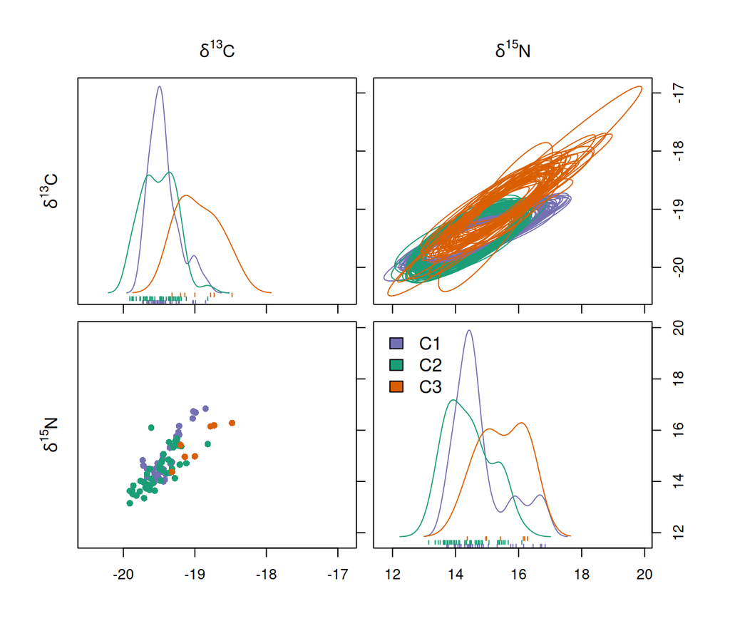

```r
clrs <- c("#7570b3", "#1b9e77", "#d95f02")[1:K]
set.seed(SEED)
iso.par50 <- tapply(seq_len(n), dat$strategy,
                    function(ii) niw.post(nsamples = 50, X = as.matrix(dat[ii, ISO])))
iso.data  <- tapply(seq_len(n), dat$strategy, function(ii) as.matrix(dat[ii, ISO]))
niche.plot(niche.par = iso.par50, niche.data = iso.data, pfrac = 0.05,
           iso.names = expression(delta^{13}*C, delta^{15}*N), col = clrs)
```

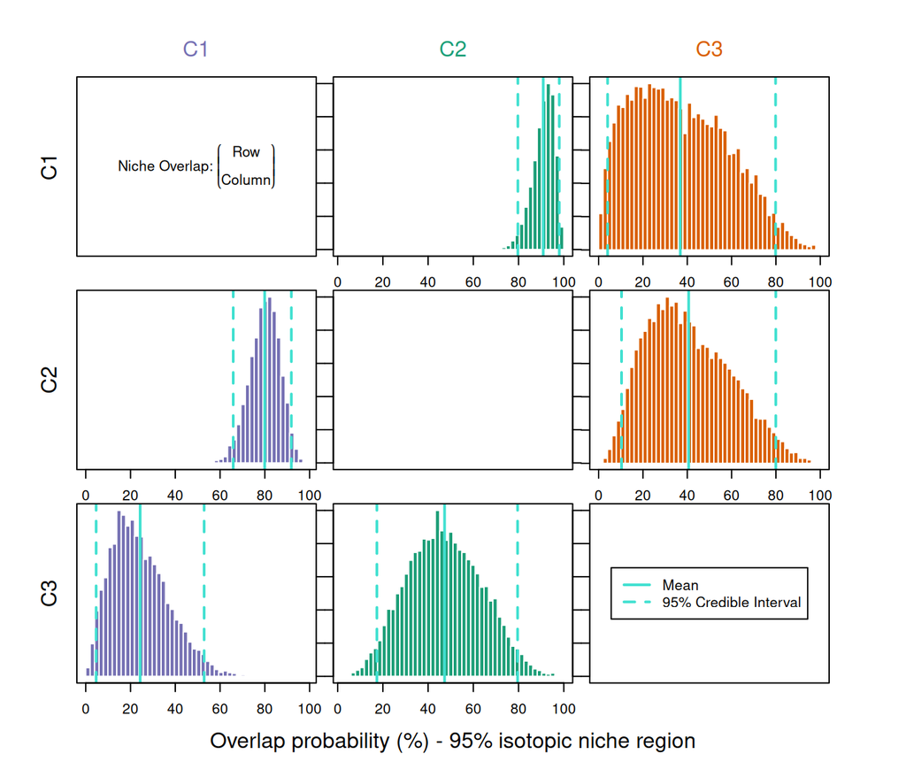

```r
overlap.plot(iso.over[, , , 1], col = clrs, mean.cred.col = "turquoise", equal.axis = TRUE,
             xlab = "Overlap probability (%) - 95% isotopic niche region")
```

**Caveats.** Isotope baselines vary among years; if the year effect in Section 4 is large, repeat with year-centred isotopes (below), remembering that centring also removes any real strategy difference confounded with year (e.g. coastal seals in 2014). Also state which tissue was sampled and the time window it integrates relative to the tracked trip.

```r
iso_c <- dat %>% group_by(ProcedureYear) %>%
  mutate(across(all_of(ISO), ~ .x - mean(.x))) %>% ungroup() %>% as.data.frame()
set.seed(SEED)
iso.par.c <- tapply(seq_len(n), iso_c$strategy,
                    function(ii) niw.post(nsamples = N_POST, X = as.matrix(iso_c[ii, ISO])))
round(apply(overlap(iso.par.c, nreps = 5000, nprob = 5000, alpha = c(0.95, 0.99)),
            c(1:2, 4), mean)[, , 1] * 100, 1)
```

```
##          Species B
## Species A   C1   C2   C3
##        C1   NA 91.2 33.8
##        C2 81.7   NA 35.6
##        C3 28.1 50.8   NA
```

## 7.2 Spatial niche (descriptive)

One kernel utilisation distribution (UD) per seal on a common equal-area grid and a common bandwidth; the strategy UD is the mean of its seals’ UDs, so each seal has equal weight regardless of track length. Overlap is measured with Bhattacharyya’s affinity (BA; 0 = none, 1 = identical) and UDOI on the 95 % isopleths (Fieberg & Kochanny 2005). Because spatial variables helped define the strategies, low between-strategy overlap is expected and is a description, not a test. The individual-level BA (within vs between strategies) shows how tightly seals within a strategy share space.

```r
tracks <- read.csv("../data/NESETracks6h.csv") %>%
  filter(Season == "PB") %>%
  mutate(TOPPID = as.character(track_id),
         longitude = ifelse(longitude > 180, longitude - 360, longitude)) %>%
  inner_join(dat %>% dplyr::select(TOPPID, strategy), by = "TOPPID")

xy  <- st_coordinates(st_transform(st_as_sf(tracks, coords = c("longitude", "latitude"),
                                            crs = 4326), LAEA))
colony_xy <- st_coordinates(st_transform(st_sfc(st_point(COLONY_LONLAT), crs = 4326), LAEA))
tracks <- tracks %>% mutate(x = xy[, 1], y = xy[, 2],
                            d_col = sqrt((x - colony_xy[1])^2 + (y - colony_xy[2])^2)) %>%
  filter(d_col > COLONY_BUFFER_KM) %>%
  group_by(TOPPID) %>% filter(n() >= 10) %>% ungroup()
seals <- tracks %>% distinct(TOPPID, strategy)
cat(nrow(seals), "seals with tracks;", nrow(tracks), "at-sea locations\n")
```

```
## 92 seals with tracks; 26806 at-sea locations
```

```r
table(seals$strategy)
```

```
##
## C1 C2 C3
## 39 46  7
```

```r
pad  <- 3 * max(KERNEL_SD_SENS)
lims <- c(range(tracks$x) + c(-pad, pad), range(tracks$y) + c(-pad, pad))
nx <- ceiling(diff(lims[1:2]) / CELL_KM) + 1
ny <- ceiling(diff(lims[3:4]) / CELL_KM) + 1
grid <- expand.grid(x = seq(lims[1], lims[2], length.out = nx),
                    y = seq(lims[3], lims[4], length.out = ny))

# Individual UDs: one column per seal, cells as rows, each column sums to 1
# (MASS::kde2d uses a Gaussian kernel with sd = h/4)
ud_individual <- function(sd_km) {
  sapply(seals$TOPPID, function(id) {
    tr <- tracks[tracks$TOPPID == id, ]
    z  <- as.vector(MASS::kde2d(tr$x, tr$y, h = 4 * sd_km, n = c(nx, ny), lims = lims)$z)
    z / sum(z)
  })
}
in_isopleth <- function(p, level) {
  o <- order(p, decreasing = TRUE); keep <- logical(length(p))
  keep[o[cumsum(p[o]) <= level]] <- TRUE; keep
}
udoi <- function(p1, p2, level = 0.95) {
  a <- in_isopleth(p1, level) & in_isopleth(p2, level)
  sum(a) * sum(p1[a] * p2[a])
}
strategy_overlap <- function(P) {
  U <- sapply(levels(dat$strategy), function(s) rowMeans(P[, seals$strategy == s, drop = FALSE]))
  BA <- crossprod(sqrt(U))
  UO <- outer(colnames(U), colnames(U), Vectorize(function(a, b) udoi(U[, a], U[, b])))
  dimnames(UO) <- dimnames(BA)
  list(U = U, BA = BA, UDOI = UO)
}
```

```r
P  <- ud_individual(KERNEL_SD_KM)
so <- strategy_overlap(P)
round(so$BA, 3)
```

```
##       C1    C2    C3
## C1 1.000 0.405 0.295
## C2 0.405 1.000 0.652
## C3 0.295 0.652 1.000
```

```r
round(so$UDOI, 3)
```

```
##       C1    C2    C3
## C1 1.274 0.087 0.056
## C2 0.087 1.212 0.405
## C3 0.056 0.405 1.808
```

```r
# Bandwidth sensitivity
sapply(KERNEL_SD_SENS, function(h) {
  o <- strategy_overlap(if (h == KERNEL_SD_KM) P else ud_individual(h))$BA
  o[upper.tri(o)]
}) %>% `colnames<-`(paste0("sd_", KERNEL_SD_SENS, "km")) %>%
  `rownames<-`(combn(levels(dat$strategy), 2, paste, collapse = "-")) %>% round(3)
```

```
##       sd_25km sd_50km sd_100km
## C1-C2   0.362   0.405    0.482
## C1-C3   0.252   0.295    0.356
## C2-C3   0.567   0.652    0.734
```

```r
# Individual-level overlap: within vs between strategies
BAi <- crossprod(sqrt(P))
pairs <- which(upper.tri(BAi), arr.ind = TRUE)
ind_ba <- data.frame(s1 = seals$strategy[pairs[, 1]], s2 = seals$strategy[pairs[, 2]],
                     BA = BAi[pairs]) %>%
  mutate(pair = ifelse(s1 == s2, paste(s1, "(within)"),
                       paste(pmin(as.character(s1), as.character(s2)),
                             pmax(as.character(s1), as.character(s2)), sep = "-")))
ind_ba %>% group_by(pair) %>%
  summarise(n_pairs = n(), median_BA = median(BA), q25 = quantile(BA, .25), q75 = quantile(BA, .75))
```

```
## # A tibble: 6 × 5
##   pair        n_pairs median_BA    q25   q75
##   <chr>         <int>     <dbl>  <dbl> <dbl>
## 1 C1 (within)     741     0.428 0.240  0.605
## 2 C1-C2          1794     0.129 0.0746 0.236
## 3 C1-C3           273     0.116 0.0605 0.186
## 4 C2 (within)    1035     0.352 0.168  0.550
## 5 C2-C3           322     0.303 0.155  0.431
## 6 C3 (within)      21     0.354 0.185  0.443
```

```r
write.csv(round(so$BA, 4), file.path(OUT, "spatial_BA_strategies.csv"))
```

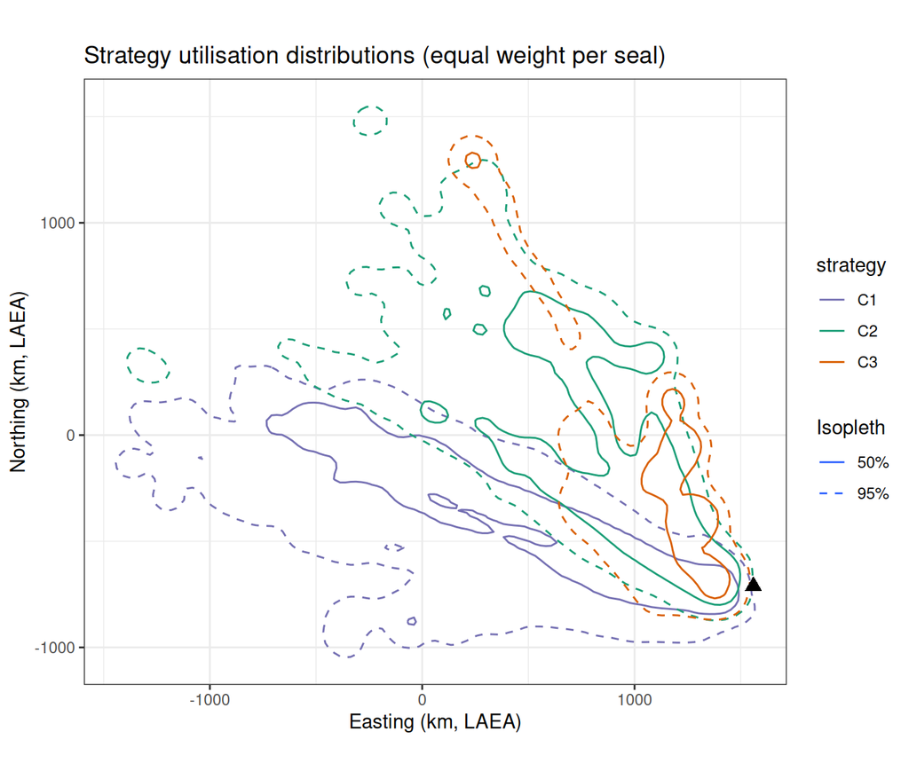

```r
iso_vol <- function(p) { o <- order(p, decreasing = TRUE); v <- numeric(length(p)); v[o] <- cumsum(p[o]); v }
map_df <- bind_rows(lapply(colnames(so$U), function(s)
  cbind(grid, strategy = s, vol = iso_vol(so$U[, s]))))
gmap <- ggplot(map_df, aes(x, y)) +
  geom_contour(aes(z = vol, colour = strategy, linetype = after_stat(factor(level))),
               breaks = c(0.5, 0.95)) +
  geom_point(data = data.frame(x = colony_xy[1], y = colony_xy[2]), shape = 17, size = 3) +
  scale_colour_manual(values = setNames(clrs, levels(dat$strategy))) +
  scale_linetype_manual(values = c(1, 2), labels = c("50%", "95%"), name = "Isopleth") +
  coord_equal() + theme_bw() +
  labs(x = "Easting (km, LAEA)", y = "Northing (km, LAEA)",
       title = "Strategy utilisation distributions (equal weight per seal)")
gmap
```

```r
ggsave(file.path(FIG, "strategy_UDs.pdf"), gmap, width = 7, height = 6)
```

## 7.3 Diving niche (descriptive)

PCA of the diving variables alone; nicheROVER in the first two diving PCs.

```r
pca_dive <- prcomp(dat[DIVE], scale. = TRUE)
summary(pca_dive)$importance[, 1:4]
```

```
##                             PC1     PC2      PC3       PC4
## Standard deviation     1.815015 1.63227 1.347371 0.9782844
## Proportion of Variance 0.299480 0.24221 0.165040 0.0870000
## Cumulative Proportion  0.299480 0.54169 0.706730 0.7937300
```

```r
round(pca_dive$rotation[, 1:2], 2)
```

```
##                                PC1   PC2
## Mean_Depth_m                  0.51 -0.08
## Mean_Depth_sd                -0.01  0.10
## Mean_Duration_sec             0.19  0.53
## Mean_Duration_sd              0.04  0.50
## Pct_TransitDives             -0.04 -0.35
## Pct_ForagingDives             0.36  0.07
## Pct_DriftDives               -0.30  0.24
## Pct_BenthicDives             -0.32  0.22
## PctTripDiving                 0.14  0.46
## DeepDayForageDivesMedian_m   -0.44  0.09
## DeepNightForageDivesMedian_m -0.41  0.02
```

```r
D2 <- pca_dive$x[, 1:2]
set.seed(SEED)
dive.par <- tapply(seq_len(n), dat$strategy, function(ii) niw.post(nsamples = N_POST, X = D2[ii, ]))
dive.size <- sapply(dive.par, function(sp) apply(sp$Sigma, 3, niche.size, alpha = 0.95))
round(apply(dive.size, 2, quantile, c(0.025, 0.5, 0.975)), 2)
```

```
##          C1    C2    C3
## 2.5%  16.89 19.93 19.43
## 50%   22.75 26.28 37.90
## 97.5% 31.63 35.37 82.98
```

```r
set.seed(SEED)
dive.over <- overlap(dive.par, nreps = 1e4, nprob = 1e4, alpha = c(0.95, 0.99))
round(apply(dive.over, c(1:2, 4), mean)[, , 1] * 100, 1)
```

```
##          Species B
## Species A C1   C2  C3
##        C1 NA 78.2 0.1
##        C2 67   NA 0.6
##        C3  0  0.2  NA
```

## 7.4 How much overlap does clustering alone create? (null model)

Seals are simulated from a single multivariate normal with the observed correlation among the 19 behavioural variables — no strategies — then run through the same pipeline (MFA → K clusters). The overlap between these artificial clusters is what would be found even if strategies did not exist. Observed overlaps are computed with the same plug-in estimator so they are directly comparable. The comparison is made for (i) the MFA space — the kind of space the original nicheROVER analysis used — and (ii) the diving-PC space. Isotopic niches need no null: isotopes were not used for clustering.

```r
R_behav <- cor(dat[BEHAV])
summ <- function(O, cl) {   # mean off-diagonal overlap and the two largest clusters' mutual overlap
  big <- names(sort(table(cl), decreasing = TRUE))[1:2]
  c(mean_offdiag = offdiag_mean(O), largest_pair = mean(c(O[big[1], big[2]], O[big[2], big[1]])))
}
set.seed(SEED)
null <- t(replicate(N_SIM, {
  Z <- as.data.frame(MASS::mvrnorm(n, rep(0, ncol(R_behav)), R_behav)); names(Z) <- BEHAV
  Sz <- mfa_coords(Z); cl <- hcpc_lite(Sz, K)
  if (min(table(cl)) < 4) return(rep(NA_real_, 4))
  Dz <- prcomp(Z[DIVE], scale. = TRUE)$x[, 1:2]
  c(summ(plugin_overlap(Sz, cl), cl), summ(plugin_overlap(Dz, cl), cl))
}))
colnames(null) <- c("MFA_mean", "MFA_pair", "Dive_mean", "Dive_pair")

set.seed(SEED)
obs <- c(summ(plugin_overlap(S, dat$strategy), dat$strategy),
         summ(plugin_overlap(D2, dat$strategy), dat$strategy))
names(obs) <- colnames(null)
null_tab <- data.frame(statistic = names(obs), observed = obs,
  null_median = apply(null, 2, median, na.rm = TRUE),
  null_lwr = apply(null, 2, quantile, 0.025, na.rm = TRUE),
  null_upr = apply(null, 2, quantile, 0.975, na.rm = TRUE),
  P_null_le_obs = sapply(names(obs), function(s) mean(null[, s] <= obs[s], na.rm = TRUE)))
null_tab %>% mutate(across(where(is.numeric), ~ round(.x, 3)))
```

```
##           statistic observed null_median null_lwr null_upr P_null_le_obs
## MFA_mean   MFA_mean    0.007       0.244    0.141    0.325             0
## MFA_pair   MFA_pair    0.022       0.249    0.070    0.389             0
## Dive_mean Dive_mean    0.252       0.363    0.283    0.586             0
## Dive_pair Dive_pair    0.756       0.345    0.173    0.649             1
```

```r
write.csv(null_tab, file.path(OUT, "overlap_null_model.csv"), row.names = FALSE)
```

Interpretation: if the observed overlap is far below the null range, the strategies are more distinct than clustering alone would produce. The *size* of the null overlap shows why overlap in the clustering space cannot by itself be reported as evidence of niche partitioning.

# 8 Summary

```r
list(
  strategies   = table(dat$strategy),
  ARI_vs_original_PCA = round(adjustedRandIndex(dat$strategy, dat$orig_cluster), 3),
  stability    = jac,
  validation   = val %>% dplyr::select(response, covariates, p_perm, p_BH),
  offshore_isotope_equivalence = tost,
  isotopic_overlap_95 = round(iso.over.mean[, , 1], 1),
  spatial_BA   = round(so$BA, 3),
  overlap_null = null_tab)
```

```
## $strategies
##
## C1 C2 C3
## 39 47  7
##
## $ARI_vs_original_PCA
## [1] 0.975
##
## $stability
##   strategy  n jaccard_mean P_dissolved
## 1       C1 39    0.9864311        0.00
## 2       C2 47    0.9421551        0.00
## 3       C3  7    0.7941082        0.16
##
## $validation
##                          response                        covariates p_perm
## 1                            d13C                              none  0.002
## 2                            d13C                     ProcedureYear  0.002
## 3                            d15N                              none  0.006
## 4                            d15N                     ProcedureYear  0.006
## 5  MassGainRate_kgPerDay_Dcrocker                              none  0.008
## 6  MassGainRate_kgPerDay_Dcrocker                 TripDuration_days  0.048
## 7  MassGainRate_kgPerDay_Dcrocker TripDuration_days + ProcedureYear  0.144
## 8               TripDuration_days                              none  0.002
## 9                       AgeDeploy                              none  0.672
## 10              StandardLength_cm                              none  0.638
## 11              Mass_Procedure_kg                              none  0.032
##           p_BH
## 1  0.007333333
## 2  0.007333333
## 3  0.013200000
## 4  0.013200000
## 5  0.014666667
## 6  0.066000000
## 7  0.176000000
## 8  0.007333333
## 9  0.672000000
## 10 0.672000000
## 11 0.050285714
##
```

[output cut: 9 more lines]

```
##        C2 79.9   NA 40.6
##        C3 24.3 47.3   NA
##
## $spatial_BA
##       C1    C2    C3
## C1 1.000 0.405 0.295
## C2 0.405 1.000 0.652
## C3 0.295 0.652 1.000
##
## $overlap_null
##           statistic    observed null_median  null_lwr  null_upr P_null_le_obs
## MFA_mean   MFA_mean 0.007433333   0.2436333 0.1407450 0.3253942             0
## MFA_pair   MFA_pair 0.022300000   0.2493000 0.0699075 0.3885875             0
## Dive_mean Dive_mean 0.252200000   0.3626000 0.2828183 0.5855842             0
## Dive_pair Dive_pair 0.755500000   0.3454000 0.1728925 0.6489775             1
```

```r
saveRDS(dat, file.path(OUT, "PB_strategies.rds"))
```